# Blood-Brain Barrier Gene Conservation Across Human, Mouse, and Macaque

- Show All Code
- Hide All Code
- View Source

Author

Yara Ismail

Published

September 9, 2026

**Introduction**

The standard preclinical pipeline for drugs targeting the brain looks like this:

> **Mouse** → validate → **Macaque** → validate → **Human clinical trial**

Each arrow is a translational leap. A drug that works in mouse must survive the jump to macaque, then to human. If the underlying molecular machinery — the blood-brain barrier (BBB) genes that control what enters and exits the brain — differs substantially between species, that pipeline is fragile. If it is conserved, the pipeline has a stronger molecular foundation.

This project asks:

> **How similar are BBB genes across all three rungs of this translational ladder — at the DNA sequence level?**

We quantify this using two complementary metrics:

- **% nucleotide identity** — how many DNA letters match between species
- **dN/dS ratio** — whether evolution is actively *protecting* these genes from protein-changing mutations (dN/dS << 1 = purifying selection)

The analysis covers three pairwise comparisons: Human vs Mouse, Human vs Macaque, and Mouse vs Macaque. BBB genes are compared against a liver control set to establish whether any conservation signal is BBB-specific or just a property of all expressed genes.

### What are “canonical BBB genes”?

The BBB is formed by brain endothelial cells (ECs) — the cells lining the brain’s blood vessels. “Canonical BBB genes” refers to genes that are *consistently identified across multiple independent transcriptomic studies* as highly expressed and functionally important in these cells. This includes:

- **Tight junction proteins** — CLDN5, OCLN, TJP1 (seal gaps between cells to block free diffusion into the brain)
- **Transporters** — SLC2A1/GLUT1 (glucose), ABCB1/P-gp (drug efflux pump), SLC7A5 (amino acids)
- **Signalling receptors** specific to brain endothelium

“Canonical” does not mean “the only important BBB genes” — it means well-validated across datasets.

### Pipeline overview

```
Step 1    Build master BBB gene list (Daneman + Munji)
Step 2    Process Wälchli single-cell EC expression
Step 3    Map gene symbols → Ensembl IDs  [HomoloGene attempt — superseded]
Step 3b   Re-run mapping via BioMart + add orthology metadata
Step 4    Download GTF genome annotations  [removed — unnecessary]
Step 4b   Cross-reference against human EC datasets
Step 4c   Build liver control set from Human Protein Atlas
Step 5a   Download CDS (coding sequence) FASTAs
Step 5b   Extract one CDS per gene (longest transcript)
Step 5b*  Alternative: Ensembl Canonical / MANE Select transcripts
Step 5c   Pairwise alignment + % identity + dN/dS for BBB genes
Step 5d   Same for liver control genes
Step 5e   Statistical comparison (Wilcoxon)
Step 5f   Recompute dN/dS with codon-aware alignment  [bug fix]
Step 5g   Multiple testing correction
Step 5h   Direct mouse vs macaque comparison
```

> **Note on step numbering:** Steps jump from 3 to 3b and from 4 to 4b — these reflect the revision history. See the relevant tabs for details.

**Audit — what’s wrong**

Every defect below is pinned to the **numbered script step** it lives in, using the script’s own filename. The step names here and the step names in the pipeline are the same names — the ambiguity in the tab labels (which bundle several steps together) is not carried into the audit.

### The count

Breaks results3Fix these and a stated conclusion changes. Steps 1, 4c, 5d.

Numbers move6Real defects that shift figures without reversing a claim.

Clean6No defect in the step itself, including both hard parts.

Open questions6Not bugs — decisions, or data the project does not have.

### Register — all 15 numbered steps

`Run` is the order the scripts actually execute in, which is **not** the order the step names imply: `step4b` writes the file `step3b` reads, so 4b runs before 3b.

[output not shown]

### Three fixes change the conclusions

1. **`step1`** — point it at Daneman **S6**, drop S3/S4/S5, retire the `Daneman_Filter` column. Replace `toupper()` with a real ortholog mapping so the 92 lost genes come back.
2. **`step4c`** — one line, so the brain filter matches the Atlas’s real region names. Then a separate decision about what the control should actually be.
3. **`step5d`** — one orthologue rule applied to both groups.

Then re-run `step5c` through `step5h`. Everything else is numbers moving, not conclusions changing.

### What we still need to figure out

These are not defects. They need a decision, a dataset, or both — and this is the section that grows as the literature review continues.

What should the control actually be?

Fixing the `step4c` filter gives a genuine liver set, but liver may not be the right comparator at all. Brain non-BBB genes, or genes matched on protein domain, would each test a different claim.

Needs — Dr. Clelland

Can the macaque arm rest on mouse-defined biology?

Every gene earned its place from a *mouse* study. Real macaque DNA is used throughout steps 5a–5h, but no macaque study tells us which genes macaque brain vessels actually switch on. The rhesus brain single-cell atlas (Science Advances 2023, ~1M nuclei, 28 regions, on CellxGene) would close this — and widens project scope.

Needs — a dataset and sign-off

Should % identity be recomputed the way dN/dS was?

Step 5f fixed dN/dS with codon-aware alignment and left identity alone. Switching `step5b` to MANE Select and re-running identity would likely remove the 224 impossible macaque scores. The canonical FASTAs already exist.

Needs — a decision, then compute time

Why did we never use Wälchli's 12 EC subtypes?

The dataset resolves capillary from arterial from venous endothelium. Step 4b collapsed all of it to a single above-zero test. The most valuable thing about the dataset is the one thing the pipeline never asked it.

Needs — a new analysis

Where did Giger 2010 come from, and what replaces it?

Logged as the macaque dataset. Its 13 samples are all human (`taxid 9606`) — the macaque in that paper belongs to Khaitovich et al. under a separate accession that was never downloaded. It also compares neurons to endothelium rather than brain to peripheral endothelium, so it is not a BBB gene list for any species.

Needs — literature review

Should step 2 be reproducible from a clean clone?

The Seurat input is gitignored and exists on one machine. The `Mitochondrial` cluster is also still sitting in the output matrix.

Needs — a housekeeping decision

**Prerequisites**

**NoteRead-only vs reproducible**

This HTML document is **read-only** — you can read the code and results but cannot run it here. To reproduce the analysis from scratch, open the scripts in RStudio (or VS Code with the R extension) and run each `scripts/step*.R` file in order.

The heavy computation (genome alignments, BioMart queries) was already run; this tutorial reads those saved outputs.

```r
suppressPackageStartupMessages({
  library(readr)
  library(dplyr)
  library(ggplot2)
  library(knitr)
})
knitr::opts_knit$set(root.dir = "..")
```

### R packages

Install all required packages before running any scripts:

```r
# CRAN packages
install.packages(c(
  "readr", "dplyr", "ggplot2", "tidyr", "knitr",
  "readxl", "homologene", "seqinr"
))

# Bioconductor packages
if (!requireNamespace("BiocManager", quietly = TRUE))
  install.packages("BiocManager")

BiocManager::install(c(
  "biomaRt",       # Ensembl cross-species orthologue queries
  "Biostrings",    # reading/writing FASTA files, DNA translation
  "pwalign"        # pairwise sequence alignment (Needleman-Wunsch)
))

# Seurat — required for Step 2 only
install.packages("Seurat")
```

### Raw data files

| File | Where to get it | Place it at |
| --- | --- | --- |
| Daneman 2010 S3 | [PLOS ONE paper](https://doi.org/10.1371/journal.pone.0013741) → Supplementary S3 | `raw_data/daneman_2010/Daneman2010_S3_CoreBBBGenes_BrainEC_Enriched.xls` |
| Daneman 2010 S4 | Same paper → Supplementary S4 | `raw_data/daneman_2010/Daneman2010_S4_BrainEC_vs_LiverEC_Enriched.xls` |
| Daneman 2010 S5 | Same paper → Supplementary S5 | `raw_data/daneman_2010/Daneman2010_S5_BrainEC_vs_LungEC_Enriched.xls` |
| Munji 2019 S5 | [Nat. Neurosci. paper](https://doi.org/10.1038/s41593-019-0468-z) → Supplementary S5 | `raw_data/munji_2019/Munji2019_S5_BBBEnrichedGenes.xlsx` |
| Wälchli 2024 Seurat object | [Nature paper](https://doi.org/10.1038/s41586-024-07069-2) → repository | `raw_data/walchli_2024/Walchli2024_AdultBrain_TemporalLobe_SortedEndothelial_SeuratObject.rds.gz` |
| HPA RNA consensus | **Auto-downloaded** by `step4c` | `raw_data/hpa_liver/rna_tissue_consensus.tsv.zip` |
| Ensembl CDS FASTAs (×3) | **Auto-downloaded** by `step5a` | `genomes/Homo_sapiens.GRCh38.113.cds.all.fa.gz` etc. |

### Directory structure

```
BBB-Gene-Conservation/
├── raw_data/
│   ├── daneman_2010/       ← Daneman .xls files
│   ├── munji_2019/         ← Munji .xlsx file
│   ├── walchli_2024/       ← Seurat .rds.gz object
│   └── hpa_liver/          ← HPA .tsv (auto-downloaded)
├── genomes/                ← CDS FASTAs (auto-downloaded; not tracked by git)
├── processed/              ← All pipeline outputs (CSVs)
└── scripts/                ← All computation scripts
```

**Step 1 — Gene List**

Breaks results **`step1_extract_BBB_genelist.R`** — wrong source tables.

Three of the four Daneman tables read here are the wrong tables. **S3** is Daneman’s pericyte-specific list, not core BBB genes; **S4** and **S5** are developmentally up- and down-regulated CNS vascular genes, not the brain-vs-liver and brain-vs-lung contrasts assumed below. **S6 — the real BBB-enriched table — was never opened.** A further 92 genes were lost silently to `toupper()` and to HomoloGene’s 2014 gene names.

### Why did we do Step 1?

Before we can measure anything, we need to know *which genes* to measure. The BBB does not have one official gene list — different research groups have profiled brain endothelial cells at different times using different technologies. Step 1 builds a single, well-annotated master list from the two most-cited published datasets, tags each gene by how stringently it was identified, and converts mouse gene symbols to human ones so the whole pipeline can work in human gene space.

**NoteData flow**

**Full script:** `scripts/step1_extract_BBB_genelist.R` **Reads:** `raw_data/daneman_2010/Daneman2010_S3/S4/S5_*.xls`, `raw_data/munji_2019/Munji2019_S5_*.xlsx` **Writes:** `processed/master_BBB_genelist.csv` **Packages:** `readxl`, `dplyr`, `readr`, `homologene`

### Why Daneman + Munji

Two foundational papers each profiled brain endothelial cells in mouse:

- **Daneman et al. 2010** — compared brain ECs to peripheral, liver, and lung ECs (supplementary tables S3, S4, S5). The S3 list is the strictest (genes enriched vs both liver AND lung).
- **Munji et al. 2019** — top CNS endothelial-enriched genes (supplementary table S5).

Mouse gene symbols from both papers were converted to human HGNC symbols using the `homologene` R package. Each gene was tagged by source paper and which Daneman filter it passed (`liver_and_lung`, `liver_only`, or `lung_only`).

### Result

```r
master <- read_csv("processed/master_BBB_genelist.csv", show_col_types = FALSE)

cat("Total genes in master list:", nrow(master), "\n\n")
```

```
Total genes in master list: 1526
```

```r
table(master$Source) |>
  as.data.frame() |>
  rename(Source = Var1, Genes = Freq) |>
  kable()
```

| Source | Genes |
| --- | --- |
| Both | 80 |
| Daneman | 1109 |
| Munji | 337 |

```r
master |>
  filter(!is.na(Daneman_Filter)) |>
  count(Daneman_Filter) |>
  kable(caption = "Daneman stringency breakdown — `liver_and_lung` is the strictest")
```

Daneman stringency breakdown — `liver_and_lung` is the strictest

| Daneman_Filter | n |
| --- | --- |
| liver_and_lung | 130 |
| liver_only | 492 |
| lung_only | 567 |

**Step 2 — Wälchli**

Clean **`step2_process_walchli_seurat.R`** — no defect in the method.

Two things to know rather than fix: the Seurat input is gitignored, so this step cannot re-run from a clean clone, and the `Mitochondrial` cluster — dying cells, not a cell type — is still present in the output matrix. The real waste is downstream: step 4b reduces this 12-subtype matrix to a single above-zero test.

### Why did we do Step 2?

The BBB gene list from Step 1 was built entirely from **mouse** data. Before trusting it as a human BBB gene list, we need to check: are these genes actually expressed in human brain endothelial cells? The Wälchli 2024 dataset is the largest and most recent single-cell atlas of the human brain vasculature, making it the best available source for that validation. Step 2 collapses the 30,000+ individual cells into per-cell-type average expression values — a format we can easily query for any gene.

**NoteData flow**

**Full script:** `scripts/step2_process_walchli_seurat.R` **Reads:** `raw_data/walchli_2024/Walchli2024_..._SeuratObject.rds.gz` **Writes:** `processed/Walchli2024_AverageExpression.csv` **Packages:** `Seurat`, `dplyr`, `readr` **Note:** Loading the Seurat object requires ~8 GB RAM and several minutes.

The Wälchli 2024 dataset is a Seurat object containing 30,000+ human brain endothelial cells annotated by EC subtype (capillary, arteriole, venule, etc.).

### What we did

Used Seurat’s `AverageExpression()` to collapse all cells into per-cell-type mean expression values, producing a gene × cell-type matrix.

The trickiest part: Seurat’s default cell identities in this object were patient ages (15, 19 years), not cell types. Running `AverageExpression()` without overriding this would have averaged across patients, not cell types. Fix: `group.by = "ECclusters"`.

### Result

```r
walchli <- read_csv("processed/Walchli2024_AverageExpression.csv",
                    show_col_types = FALSE)

cat("Wälchli expression matrix:", nrow(walchli), "genes x",
    ncol(walchli) - 1, "cell types\n\n")
```

```
Wälchli expression matrix: 26666 genes x 12 cell types
```

```r
cat("Cell types:\n")
```

```
Cell types:
```

```r
cat(paste("  -", colnames(walchli)[-1], collapse = "\n"))
```

```
  - Angiogenic.capillary
  - Arteriole
  - Artery
  - Capillary
  - EndoMT
  - Large.artery
  - Large.vein
  - Mitochondrial
  - Proliferating.cell
  - Stem.to.EC
  - Vein
  - Venule
```

**Steps 3 & 3b — Mapping**

92 genes lost **`step3_map_ensembl_crossspecies.R`** — inherited breakage.

The 92 gene names broken in step 1 return nothing from BioMart and drop out of every downstream calculation with no error raised. The step itself is doing what it was asked.

Overstated fix **`step3b_biomart_orthology_confidence.R`** — recovers nothing.

The script header says it recovers the genes step 1 dropped. It does not: it re-queries the same out-of-date names and recovers **none of the 92**. This is also where 196 one-to-many pairs enter the BBB set at only **25.8% protein identity** — pairs that step 5d then excludes from the control set but not from the BBB set.

Circular check **`step3c_biotype_check.R`** — cannot fail.

A CDS FASTA contains only protein-coding genes by definition, so a non-coding gene has no entry, comes back blank, and blank was not counted as a failure. The reassuring “all protein-coding, no annotation gap” result below was guaranteed by the method, not earned by it. 250 rows have no macaque label at all and were invisible to the check.

Naming **Execution order does not match the step names.**

`step4b` writes `master_BBB_genelist_validated.csv`, which `step3b` reads. The true order is **1 → 2 → 3 → 4b → 3b → 3c → 4c → 5a…**, so step 4b runs *before* step 3b despite the numbering. The Audit tab’s register lists the real run order.

### Why did we do Steps 3 & 3b?

To compare DNA sequences across species, we need a stable, species-specific identifier for each gene — not the gene symbol (which changes between species, e.g. human *SLC2A1* vs mouse *Slc2a1*), but a permanent database ID. Ensembl gene IDs (`ENSG...` for human, `ENSMUSG...` for mouse, `ENSMMUG...` for macaque) serve this purpose. This step also retrieves orthologue relationships: which mouse gene corresponds to which human gene, and whether it is a clean one-to-one match or a more complex one-to-many (gene duplication) case. That distinction matters a lot for interpreting conservation scores.

**NoteData flow**

**Full scripts:** `scripts/step3_map_ensembl_crossspecies.R` (superseded), `scripts/step3b_biomart_orthology_confidence.R` **Reads:** `processed/master_BBB_genelist.csv` → `processed/master_BBB_genelist_validated.csv` + `processed/BBB_genes_crossspecies_ensembl.csv` **Writes:** `processed/master_BBB_genelist_complete.csv` **Packages:** `biomaRt`, `dplyr`, `readr` **Note:** BioMart queries require internet and take 5–15 minutes. Results are cached.

**WarningWhat went wrong — and why there is no Step 3a**

The first attempt used the `homologene` R package — an offline NCBI orthologue database — to map all three species simultaneously. This worked for human → mouse but **returned no results for macaque**: HomoloGene does not include rhesus macaque (*Macaca mulatta*).

Step 3b re-ran everything via **Ensembl BioMart**, which supports all three species and additionally returns orthologue type and pre-computed % sequence identity. This is why the pipeline skips from Step 3 to Step 3b.

### What we did

Three queries to Ensembl BioMart (each uses a different attribute page, so they cannot be combined):

1. Human gene symbol → human Ensembl gene ID (`ENSG...`)
2. Human Ensembl ID → mouse orthologue (`ENSMUSG...`)
3. Human Ensembl ID → macaque orthologue (`ENSMMUG...`)

Step 3b added `orthology_type` and `perc_id` per orthologue.

### Result

```r
combined <- read_csv("processed/master_BBB_genelist_complete.csv",
                     show_col_types = FALSE)

cat("Total rows in master table:", nrow(combined), "\n")
```

```
Total rows in master table: 1724
```

```r
cat("  Human Ensembl IDs:   ", sum(!is.na(combined$HumanEnsembl)), "\n")
```

```
  Human Ensembl IDs:    1632
```

```r
cat("  Mouse orthologues:   ", sum(!is.na(combined$MouseEnsembl)), "\n")
```

```
  Mouse orthologues:    1541
```

```r
cat("  Macaque orthologues: ", sum(!is.na(combined$MacaqueEnsembl)), "\n")
```

```
  Macaque orthologues:  1474
```

```r
combined |>
  filter(!is.na(Mouse_OrthoType)) |>
  count(Mouse_OrthoType) |>
  kable(caption = "Mouse orthologue type distribution")
```

Mouse orthologue type distribution

| Mouse_OrthoType | n |
| --- | --- |
| ortholog_many2many | 18 |
| ortholog_one2many | 196 |
| ortholog_one2one | 1327 |

The 1,724 rows (vs 1,526 input genes) reflects **one-to-many** orthologues — e.g. human ABCB1 maps to both mouse *Abcb1a* and *Abcb1b*. Both rows are kept and flagged.

### Step 3c — Biotype audit

**NoteData flow**

**Full script:** `scripts/step3c_biotype_check.R` **Reads:** `genomes/*.cds.all.fa.gz` (×3 species, already downloaded), `processed/master_BBB_genelist_complete.csv` **Writes:** `processed/gene_biotype_check.csv`, `processed/gene_biotype_summary.txt` **Packages:** `Biostrings`, `dplyr`, `readr` **Note:** Biotypes are parsed directly from the `gene_biotype:` field in Ensembl FASTA headers — no BioMart query needed.

#### Why did we do Step 3c?

We need to confirm that every gene that entered the CDS alignment pipeline is actually **protein-coding**. If any noncoding genes (lncRNAs, pseudogenes, T-cell receptor segments, etc.) were in the master list and somehow extracted a sequence, the analysis would not correctly reflect conservation of BBB coding sequences. This step audits every Ensembl ID in the master list against the `gene_biotype` annotation embedded in the FASTA headers and checks whether any flagged genes appear in the BBB CDS files.

#### Result

```r
biotype_check <- read_csv("processed/gene_biotype_check.csv",
                          show_col_types = FALSE)

# Biotype breakdown for human
bt_human <- biotype_check |>
  filter(!is.na(Human_Biotype)) |>
  count(Human_Biotype, name = "Genes") |>
  arrange(desc(Genes))

kable(bt_human, caption = "Human gene biotype distribution in BBB master list")
```

Human gene biotype distribution in BBB master list

| Human_Biotype | Genes |
| --- | --- |
| protein_coding | 1631 |

```r
n_noncoding <- sum(biotype_check$Any_NonCoding, na.rm = TRUE)
n_total     <- nrow(biotype_check)

cat(sprintf("Genes with any noncoding annotation: %d / %d\n", n_noncoding, n_total))
```

```
Genes with any noncoding annotation: 0 / 1724
```

```r
if (n_noncoding == 0) {
  cat("\nAll mapped genes are protein_coding in all three species.\n")
  cat("Pipeline integrity: CONFIRMED — no noncoding genes entered the CDS alignment.\n")
} else {
  biotype_check |>
    filter(Any_NonCoding) |>
    select(GeneSymbol_Human, HumanEnsembl, Human_Biotype,
           Mouse_Biotype, Macaque_Biotype) |>
    kable(caption = "Noncoding genes flagged in BBB master list")
}
```

```
All mapped genes are protein_coding in all three species.
Pipeline integrity: CONFIRMED — no noncoding genes entered the CDS alignment.
```

**NoteAudit outcome**

**Steps 4b & 4c — Validation**

Two reading bugs **`step4b_human_validation.R`** — the score means less than it looks.

**Yang** S6 was read without naming a sheet, so only the *first* of seven sheets loaded. That column really means “is an arterial marker” — 36 hits — and the **capillary sheet, the most BBB-relevant one, was never opened**. **Wälchli’s** test was “expression above zero in any cell type”, which **88.5% of all genes pass**; that single component is why 1,131 of 1,526 genes score exactly 1. Winkler’s parse is correct.

Consequence: `Human_BBB_Datasets_N` is close to a constant, so any result stratified on it — including “conservation and human BBB expression are independent” — is uninformative rather than negative.

Breaks results **`step4c_liver_control_geneset.R`** — the brain filter never ran.

The filter looked for a tissue called `"brain"`. The Human Protein Atlas has no such label — it lists regions: cerebral cortex, hippocampal formation, cerebellum. **Zero rows matched**, the missing values became zeros, and everything passed. The tell is sitting in the saved file: every `Brain_nTPM` value is exactly `0.0`.

Recomputed properly, **86.6% of the “liver control” genes are also expressed in brain**, and their median brain expression (31.3) matches their median liver expression (31.2). This is not a liver control — it is a general housekeeping set, and housekeeping genes are among the most conserved in the genome, which biases every BBB-vs-control comparison in a known direction.

### Why did we do Steps 4b & 4c?

Two separate questions are answered here:

**Step 4b** — The gene list comes from mouse studies, but we are ultimately interested in the *human* BBB. Before running thousands of alignments, we want to flag which genes have cross-species expression evidence in human brain endothelium (using three independent human EC datasets). This does not remove any genes — it gives each gene a confidence score (0–3) that can be used for sensitivity analysis later.

**Step 4c** — The core scientific question is whether BBB genes are *unusually* conserved, not just conserved. To answer that, we need something to compare against. A liver control set provides a biologically meaningful baseline: liver is a highly expressed, well-studied tissue, so if BBB genes are more conserved than liver genes, that difference is real and not just a property of all expressed genes.

**WarningWhat went wrong — and why Step 4 was removed**

Step 4 downloaded full **GTF genome annotation files** (~1.5 GB per species, ×3 = ~4.5 GB total) with the intention of extracting CDS coordinates manually. After downloading all three we found that Ensembl already provides **pre-extracted CDS FASTA files** (~20 MB per species) — the same information at a fraction of the size. Step 4 was removed entirely, which is why the numbering jumps from Step 3b to Step 4b.

### Step 4b — Human EC Validation

**NoteData flow**

**Full script:** `scripts/step4b_human_validation.R` **Reads:** `processed/master_BBB_genelist.csv`, `processed/Walchli2024_AverageExpression.csv` (+ Yang 2022 and Winkler 2022 gene lists, hardcoded) **Writes:** `processed/master_BBB_genelist_validated.csv` **Packages:** `dplyr`, `readr`

The master BBB gene list was built from **mouse** studies. Step 4b checks which genes are also expressed in **human** brain endothelium using three independent datasets:

- **Wälchli 2024** — expressed > 0 in any EC cluster
- **Yang 2022** — 112-gene endothelial subtype marker list
- **Winkler 2022** — EC marker list from a large human brain vascular atlas

Each gene receives a count (0–3) of how many datasets confirm it.

```r
combined <- read_csv("processed/master_BBB_genelist_complete.csv",
                     show_col_types = FALSE)

combined |>
  count(Human_BBB_Datasets_N) |>
  rename(`# datasets confirming` = Human_BBB_Datasets_N, Genes = n) |>
  kable(caption = "Human EC validation score distribution")
```

Human EC validation score distribution

| # datasets confirming | Genes |
| --- | --- |
| 0 | 74 |
| 1 | 1320 |
| 2 | 299 |
| 3 | 31 |

74 genes have zero human EC evidence — they came purely from mouse data and are flagged in downstream analysis.

### Step 4c — Liver Control Gene Set

**NoteData flow**

**Full script:** `scripts/step4c_liver_control_geneset.R` **Reads:** `processed/master_BBB_genelist_complete.csv`, `raw_data/hpa_liver/rna_tissue_consensus.tsv` (auto-downloaded) **Writes:** `processed/liver_control_genelist.csv` **Packages:** `dplyr`, `readr`

Liver was chosen as the control tissue — metabolically active and highly conserved, providing a meaningful non-BBB baseline. Filtered for genes with liver nTPM ≥ 10 that are NOT in the BBB master list.

```r
liver_ctl <- read_csv("processed/liver_control_genelist.csv", show_col_types = FALSE)
cat("Liver control set:", nrow(liver_ctl), "genes\n")
```

```
Liver control set: 7131 genes
```

```r
cat("Liver nTPM — median:", round(median(liver_ctl$Liver_nTPM), 1),
    " mean:", round(mean(liver_ctl$Liver_nTPM), 1), "\n")
```

```
Liver nTPM — median: 31.2  mean: 346.1
```

Landmark liver genes confirmed present: ALB (198,523 nTPM), CYP3A4, APOB, TTR.

**Steps 5a-b — CDS**

Clean **`step5a_download_cds_fastas.R`** — Ensembl 113, all three species.

Rough heuristic **`step5b_extract_cds_sequences.R`** — longest ≠ equivalent.

Taking the longest isoform means human and mouse can land on **non-corresponding versions of the same gene**, which makes them look more different than they are. This is the origin of the 224 impossible macaque scores that appear in step 5c.

`step5b_alt_canonical_transcripts.R` implements the standard alternative — MANE Select / Ensembl Canonical — and the canonical FASTAs already sit in `genomes/`. **It was written and never switched in.**

### Why did we do Steps 5a-b?

Conservation analysis works at the DNA sequence level — we need the actual nucleotide letters for each gene in each species. The full genome of a mammal is ~3 billion base pairs, but most of that is non-coding (introns, regulatory regions, intergenic space). We only want the **coding sequence (CDS)** — the stretch of DNA that actually gets translated into protein. Ensembl provides pre-extracted CDS files for every annotated transcript, which are ~150× smaller than the full genome files and much faster to work with. Step 5b then extracts just the CDS sequences for our specific BBB and liver gene lists, ready for alignment.

**NoteData flow**

**Full scripts:** `scripts/step5a_download_cds_fastas.R`, `scripts/step5b_extract_cds_sequences.R` **Step 5a** downloads Ensembl CDS FASTAs → `genomes/*.cds.all.fa.gz` (×3 species) **Step 5b reads:** genome FASTAs + gene lists → **Writes:** `genomes/cds_BBB_*.fa` and `genomes/cds_liver_*.fa` (×3 species each) **Packages:** `Biostrings`, `dplyr`, `readr` **Note:** `genomes/` is excluded from git (too large). Run Step 5a to populate it before Step 5b.

### What we did

Ensembl provides pre-extracted CDS FASTA files for every annotated transcript. For each gene with multiple transcripts (alternative splicing), we kept the **longest CDS** as a heuristic for the full open reading frame.

> **Alternative:** `scripts/step5b_alt_canonical_transcripts.R` uses **Ensembl Canonical / MANE Select** transcripts instead — one curated transcript per gene, jointly designated by NCBI + EMBL-EBI. The FASTAs are already generated in `genomes/cds_canonical_*.fa`.

### Result

```r
library(Biostrings)
bbb_human <- readDNAStringSet("genomes/cds_BBB_human.fa")
cat("Human BBB CDS sequences:", length(bbb_human), "\n")
```

```
Human BBB CDS sequences: 1433
```

```r
cat("Length: median =", as.integer(median(width(bbb_human))), "bp\n")
```

```
Length: median = 1449 bp
```

```r
cat("        mean   =", as.integer(mean(width(bbb_human))), "bp\n")
```

```
        mean   = 1913 bp
```

**Steps 5c-d — Scoring**

Partly superseded **`step5c_align_and_score.R`** — dN/dS fixed later, % identity never was.

dN/dS here was computed on sequences that were trimmed but never actually aligned. That is genuinely wrong, and it is correctly fixed in step 5f. But the **% identity was never recomputed**, so *every identity figure in the results still comes from this step*.

Two numbers show the size of the problem. **38% of genes came out with dS pinned at the 10.0 ceiling** — saturated nonsense — which falls to **2%** after the codon-aware fix. And **224 one-to-one macaque pairs score under 85%**, with `SLC2A1` at 71.4% where macaque should sit near 97%. That is step 5b’s longest-transcript heuristic picking non-corresponding isoforms, then `PID1` dividing by the longer alignment and reporting the length difference as evolutionary distance.

Breaks results **`step5d_liver_scoring.R`** — the two sides were scored under different rules.

Described as “the same measurements”, but the control set kept only the **single best-matching** orthologue per gene while the BBB set kept **every** match, including the 196 one-to-many pairs at 25.8% identity admitted in step 3b. The BBB group was carrying dead weight the control group was not.

That alone reverses the headline direction: as published, BBB 84.12 vs liver 84.32 (BBB looks *less* conserved); under one rule for both sides, BBB 85.04 vs liver 84.47 (BBB is *more* conserved).

### Why did we do Steps 5c-d?

This is the core of the project — the step that actually measures conservation. For each BBB gene (and each liver control gene), we align its coding sequence between species and compute two numbers: how similar the DNA letters are (% identity), and whether evolution is actively protecting the gene from protein-changing mutations (dN/dS). Running this for both BBB genes and liver genes separately sets up the statistical comparison in Step 5e: are BBB genes more conserved than a typical expressed gene?

**NoteData flow**

**Full scripts:** `scripts/step5c_align_and_score.R` (BBB), `scripts/step5d_liver_scoring.R` (liver) **Reads:** `genomes/cds_BBB_*.fa` or `genomes/cds_liver_*.fa`, `processed/master_BBB_genelist_complete.csv` **Writes:** `processed/conservation_scores_BBB.csv`, `processed/conservation_scores_liver.csv`, `processed/conservation_scores_combined.csv` **Packages:** `Biostrings`, `pwalign`, `seqinr`, `dplyr`, `readr` **Note:** Step 5c takes 20–40 min (~1,500 alignments). Step 5d takes 60–90 min (~3,000 alignments).

### Pairwise global alignment

For each gene we ran a **Needleman-Wunsch global alignment** between species pairs, then computed % identity and dN/dS:

```r
aln <- pwalign::pairwiseAlignment(
  seq1, seq2, type = "global",
  substitutionMatrix = nucleotideSubstitutionMatrix(match=1, mismatch=-1),
  gapOpening = -5, gapExtension = -2
)
pct_identity <- pwalign::pid(aln, type = "PID1")
# PID1 = matches / alignment_length (including gaps)
```

**Why global, not local?** These are orthologous genes — they should align end-to-end. Local alignment would only find the most similar segment, over-estimating similarity for genes that diverge at the edges.

### Why % identity AND dN/dS

- **% identity** — how similar are the letters, simple and interpretable
- **dN/dS** — how often do mutations *change the protein* (non-synonymous, dN) vs leave it unchanged (synonymous, dS). dN/dS << 1 means evolution is removing protein-changing mutations (purifying selection).

**Steps 5e-g — Statistics**

Clean **`step5e_statistics.R`, `step5f_recompute_dnds.R`, `step5g_stats_v2.R`** — all three correct.

The statistical framework is sound: the right tests for non-normal data, correctly corrected, with subgroup analyses honestly labelled exploratory. **Step 5f is the project’s one real fix** — the codon-aware recomputation moved one-to-many mouse dN/dS from 0.14 to 0.354 and dropped saturated dS from 38% of genes to 2%.

What is wrong is what went *into* these tests: the gene list from step 1, the control set from step 4c, and the asymmetric orthologue rule from step 5d. Step 5f’s only gap is scope — it fixed dN/dS and left % identity untouched.

### Why did we do Steps 5e-g?

Having conservation scores for ~4,500 gene pairs is not enough on its own — we need to know whether the differences between BBB and liver genes are statistically meaningful or just random variation. Step 5e runs the formal tests. Steps 5f and 5g were added specifically because the initial dN/dS values were wrong (see the bug callout below): Step 5f recomputes them correctly using a codon-aware alignment pipeline, and Step 5g re-runs the statistics on the corrected values with proper multiple testing correction applied.

**NoteData flow**

**Full scripts:** `scripts/step5e_statistics.R`, `scripts/step5f_recompute_dnds.R`, `scripts/step5g_stats_v2.R` **Step 5e** reads `conservation_scores_combined.csv` → writes `conservation_summary.txt` **Step 5f** reads combined scores + CDS FASTAs → **writes** `conservation_scores_combined_v2.csv` **Step 5g** reads v2 scores → writes `conservation_summary_v2.txt` **Packages:** `Biostrings`, `pwalign`, `seqinr`, `dplyr`, `readr`

### Step 5e: First-pass statistics

Wilcoxon rank-sum tests comparing BBB vs liver (non-parametric, because % identity is bounded and skewed). Stratified analyses by Daneman filter, validation score, and orthologue type.

### Step 5f: dN/dS recomputation

**WarningWhat went wrong — three separate dN/dS bugs**

**Bug 1 — all NA values:** The `ape` package (loaded alongside `seqinr`) has its own `kaks()` function and silently overrode `seqinr::kaks()`. Fix: explicit namespace.

**Bug 2 — values inflated:** `seqinr::kaks()` assumes codon-aligned input — same length, same reading frame positions in both sequences. We were passing unaligned sequences, inflating the non-synonymous count. Especially large effect for human vs mouse (~80 million year divergence).

**Bug 3 — wrong translation function:** `dplyr`’s `translate()` (an SQL function) was silently overriding `Biostrings::translate()`. Fix: `Biostrings::translate(DNAString(seq), if.fuzzy.codon = "X")`.

**The fix:** translate both sequences to amino acids → align proteins with BLOSUM62 → back-map codons using protein alignment → strip gap columns → pass codon-aligned pair to `seqinr::kaks()`:

```r
aa1 <- Biostrings::translate(DNAString(nt1), if.fuzzy.codon = "X")
aa2 <- Biostrings::translate(DNAString(nt2), if.fuzzy.codon = "X")
protein_aln <- pwalign::pairwiseAlignment(aa1, aa2, type = "global",
                 substitutionMatrix = "BLOSUM62",
                 gapOpening = 10, gapExtension = 4)
# back-map to codons, strip gaps, run seqinr::kaks()
# full implementation: scripts/step5f_recompute_dnds.R
```

### Step 5g: Multiple testing correction

Bonferroni and FDR (Benjamini-Hochberg) applied to the four primary BBB-vs-liver comparisons. Stratified tests are flagged as exploratory.

### Final results

```r
df <- read_csv("processed/conservation_scores_combined_v2.csv",
               show_col_types = FALSE)

bbb   <- df[df$Gene_Set == "BBB", ]
liver <- df[df$Gene_Set == "Liver_Control", ]

results <- data.frame(
  Comparison = c("Human vs Mouse — % identity",
                  "Human vs Macaque — % identity",
                  "Human vs Mouse — dN/dS (corrected)",
                  "Human vs Macaque — dN/dS (corrected)"),
  BBB_median = c(
    round(median(bbb$PctId_Human_Mouse,      na.rm = TRUE), 2),
    round(median(bbb$PctId_Human_Macaque,    na.rm = TRUE), 2),
    round(median(bbb$dNdS_Human_Mouse_v2,    na.rm = TRUE), 3),
    round(median(bbb$dNdS_Human_Macaque_v2,  na.rm = TRUE), 3)
  ),
  Liver_median = c(
    round(median(liver$PctId_Human_Mouse,      na.rm = TRUE), 2),
    round(median(liver$PctId_Human_Macaque,    na.rm = TRUE), 2),
    round(median(liver$dNdS_Human_Mouse_v2,    na.rm = TRUE), 3),
    round(median(liver$dNdS_Human_Macaque_v2,  na.rm = TRUE), 3)
  )
)
kable(results, caption = "BBB vs liver conservation — final corrected values")
```

BBB vs liver conservation — final corrected values

| Comparison | BBB_median | Liver_median |
| --- | --- | --- |
| Human vs Mouse — % identity | 84.120 | 84.320 |
| Human vs Macaque — % identity | 96.820 | 96.150 |
| Human vs Mouse — dN/dS (corrected) | 0.117 | 0.119 |
| Human vs Macaque — dN/dS (corrected) | 0.152 | 0.196 |

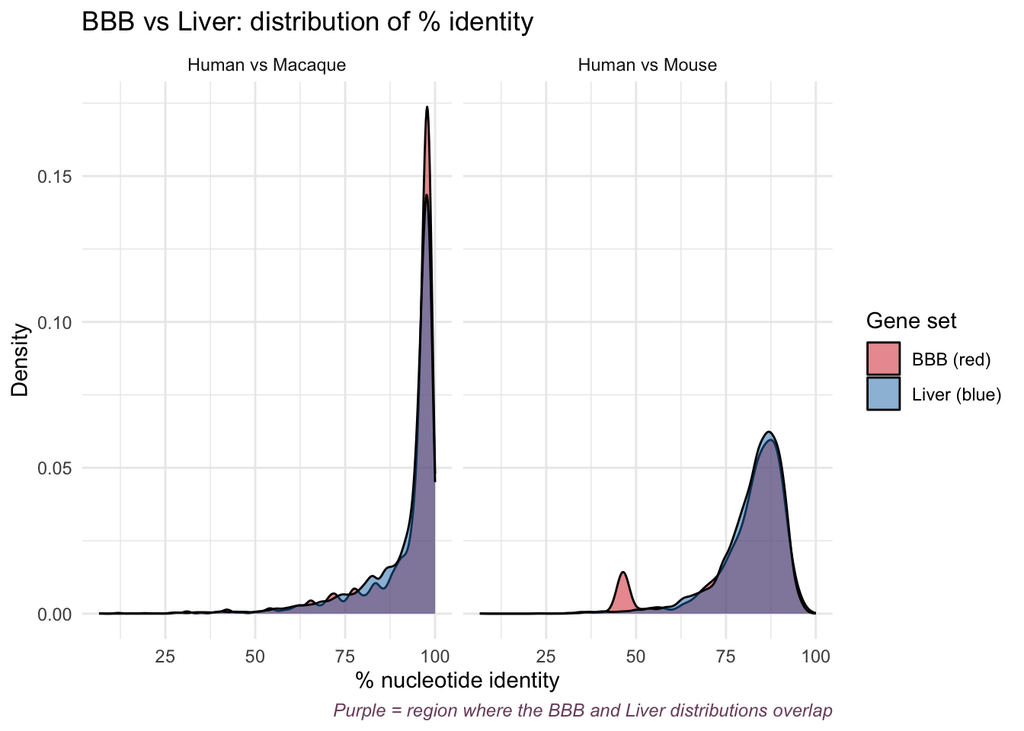

Distribution of % nucleotide identity — BBB vs Liver

```r
df_long <- df |>
  select(Gene_Set, PctId_Human_Mouse, PctId_Human_Macaque) |>
  tidyr::pivot_longer(cols = -Gene_Set, names_to = "Comparison",
                       values_to = "PctIdentity") |>
  filter(!is.na(PctIdentity)) |>
  mutate(Comparison = sub("PctId_", "", Comparison),
         Comparison = sub("_", " vs ", Comparison))

ggplot(df_long, aes(x = PctIdentity, fill = Gene_Set)) +
  geom_density(alpha = 0.5) +
  facet_wrap(~ Comparison) +
  scale_fill_manual(
    values = c("BBB" = "#d62728", "Liver_Control" = "#1f77b4"),
    labels = c("BBB" = "BBB (red)", "Liver_Control" = "Liver (blue)")
  ) +
  labs(x = "% nucleotide identity", y = "Density",
       title = "BBB vs Liver: distribution of % identity",
       fill = "Gene set",
       caption = "Purple = region where the BBB and Liver distributions overlap") +
  theme_minimal() +
  theme(plot.caption = element_text(colour = "#7b4f6e", face = "italic", size = 9))
```

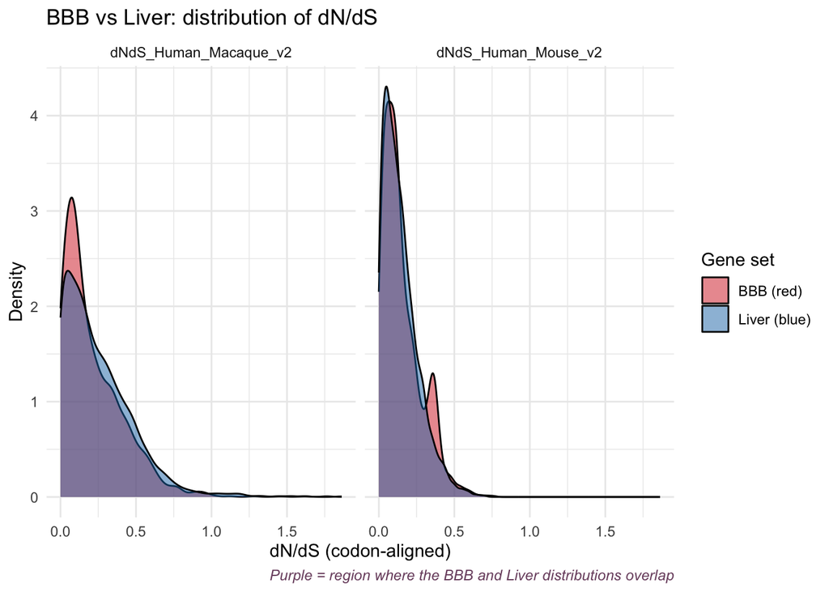

Distribution of dN/dS (codon-aligned)

```r
df_dnds <- df |>
  select(Gene_Set, dNdS_Human_Mouse_v2, dNdS_Human_Macaque_v2) |>
  tidyr::pivot_longer(cols = -Gene_Set, names_to = "Comparison", values_to = "dNdS") |>
  filter(!is.na(dNdS), dNdS < 2)

ggplot(df_dnds, aes(x = dNdS, fill = Gene_Set)) +
  geom_density(alpha = 0.5) +
  facet_wrap(~ Comparison) +
  scale_fill_manual(
    values = c("BBB" = "#d62728", "Liver_Control" = "#1f77b4"),
    labels = c("BBB" = "BBB (red)", "Liver_Control" = "Liver (blue)")
  ) +
  labs(x = "dN/dS (codon-aligned)", y = "Density",
       title = "BBB vs Liver: distribution of dN/dS",
       fill = "Gene set",
       caption = "Purple = region where the BBB and Liver distributions overlap") +
  theme_minimal() +
  theme(plot.caption = element_text(colour = "#7b4f6e", face = "italic", size = 9))
```

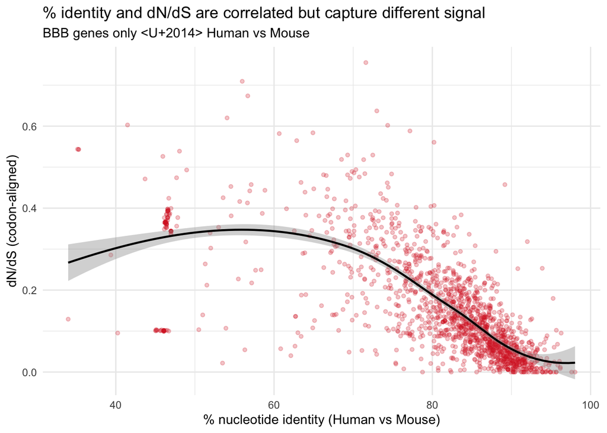

```r
bbb_scatter <- bbb |>
  filter(!is.na(PctId_Human_Mouse), !is.na(dNdS_Human_Mouse_v2), dNdS_Human_Mouse_v2 < 2)

ggplot(bbb_scatter, aes(x = PctId_Human_Mouse, y = dNdS_Human_Mouse_v2)) +
  geom_point(alpha = 0.25, color = "#d62728", size = 1.2) +
  geom_smooth(method = "loess", se = TRUE, color = "black", linewidth = 0.8) +
  labs(x = "% nucleotide identity (Human vs Mouse)", y = "dN/dS (codon-aligned)",
       title = "% identity and dN/dS are correlated but capture different signal",
       subtitle = "BBB genes only — Human vs Mouse") +
  theme_minimal()
```

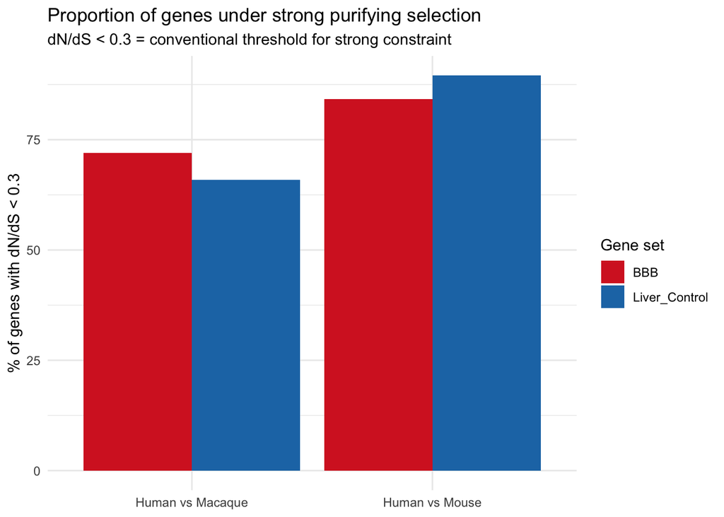

Proportion of genes under strong purifying selection (dN/dS < 0.3)

```r
purify_df <- df |>
  filter(!is.na(dNdS_Human_Mouse_v2) | !is.na(dNdS_Human_Macaque_v2)) |>
  group_by(Gene_Set) |>
  summarise(
    `Human vs Mouse`   = mean(dNdS_Human_Mouse_v2   < 0.3, na.rm = TRUE) * 100,
    `Human vs Macaque` = mean(dNdS_Human_Macaque_v2 < 0.3, na.rm = TRUE) * 100,
    .groups = "drop"
  ) |>
  tidyr::pivot_longer(cols = -Gene_Set, names_to = "Comparison", values_to = "Pct")

ggplot(purify_df, aes(x = Comparison, y = Pct, fill = Gene_Set)) +
  geom_col(position = "dodge") +
  scale_fill_manual(values = c("BBB" = "#d62728", "Liver_Control" = "#1f77b4")) +
  labs(x = NULL, y = "% of genes with dN/dS < 0.3",
       title = "Proportion of genes under strong purifying selection",
       subtitle = "dN/dS < 0.3 = conventional threshold for strong constraint",
       fill = "Gene set") +
  theme_minimal()
```

**Step 5h — Triangle**

Clean **`step5h_mouse_vs_macaque.R`** — no defect of its own.

Same codon-aware pipeline, no human reference. It inherits the step 1 gene list, so its numbers move when step 1 is fixed — but the method is sound and the triangle is a genuine sanity check.

### Why did we do Step 5h?

Steps 5c–g compared every species against **human** as the reference point. But the translational pipeline runs Mouse → Macaque → Human, which means the Mouse–Macaque leg is just as important as the others. If mouse and macaque are very different from each other, a drug validated in mouse might fail in macaque for reasons unrelated to human biology. Step 5h closes the triangle by computing mouse vs macaque conservation directly, giving us the complete three-way picture needed to evaluate the full translational ladder.

**NoteData flow**

**Full script:** `scripts/step5h_mouse_vs_macaque.R` **Reads:** `genomes/cds_BBB_mouse.fa`, `genomes/cds_BBB_macaque.fa`, full genome FASTAs, `processed/conservation_scores_combined_v2.csv` **Writes:** `processed/conservation_scores_mouse_macaque.csv` **Note:** ~1,500 alignments, ~30 minutes.

Earlier steps used human as the reference. To complete the picture we computed the third side: mouse vs macaque directly.

```r
mm     <- read_csv("processed/conservation_scores_mouse_macaque.csv",
                   show_col_types = FALSE)
mm_bbb <- mm[mm$Gene_Set == "BBB", ]

triangle <- data.frame(
  Comparison = c("Human  vs Mouse", "Human  vs Macaque", "Mouse  vs Macaque"),
  `Median % identity (BBB genes)` = c(
    round(median(bbb$PctId_Human_Mouse,      na.rm = TRUE), 1),
    round(median(bbb$PctId_Human_Macaque,    na.rm = TRUE), 1),
    round(median(mm_bbb$PctId_Mouse_Macaque, na.rm = TRUE), 1)
  ),
  check.names = FALSE
)
kable(triangle)
```

| Comparison | Median % identity (BBB genes) |
| --- | --- |
| Human vs Mouse | 84.1 |
| Human vs Macaque | 96.8 |
| Mouse vs Macaque | 82.6 |

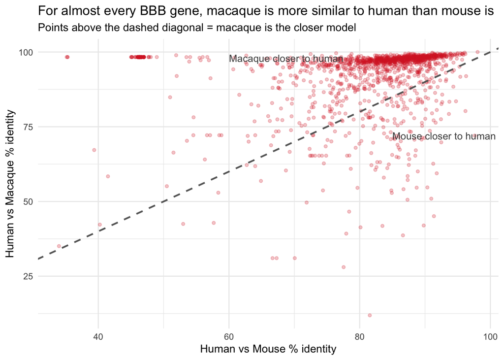

Human vs Mouse and Human vs Macaque % identity per BBB gene

```r
bbb_both <- bbb |>
  filter(!is.na(PctId_Human_Mouse), !is.na(PctId_Human_Macaque))

ggplot(bbb_both, aes(x = PctId_Human_Mouse, y = PctId_Human_Macaque)) +
  geom_point(alpha = 0.25, color = "#d62728", size = 1.2) +
  geom_abline(slope = 1, intercept = 0, linetype = "dashed",
              color = "grey40", linewidth = 0.8) +
  annotate("text", x = 60, y = 98, label = "Macaque closer to human",
           color = "grey30", size = 3.5, hjust = 0) +
  annotate("text", x = 85, y = 72, label = "Mouse closer to human",
           color = "grey30", size = 3.5, hjust = 0) +
  labs(x = "Human vs Mouse % identity", y = "Human vs Macaque % identity",
       title = "For almost every BBB gene, macaque is more similar to human than mouse is",
       subtitle = "Points above the dashed diagonal = macaque is the closer model") +
  theme_minimal()
```

The complete evolutionary distance picture:

```
                Human
              /        \
          84.1%        96.8%
            /              \
        Mouse  ── 82.6% ── Macaque
```

**Results — provisional**

#### These findings are provisional pending three fixes

Steps **1**, **4c** and **5d** feed everything below. Until they are corrected and steps 5c–5h re-run, no figure on this page should be cited. Each finding carries its own verdict underneath. One comparison already reverses direction once the orthologue rule is applied symmetrically:

As published — every match kept on the BBB side onlyBBB 84.12 · liver 84.32BBB less conserved

Same rule applied to both sidesBBB 85.04 · liver 84.47BBB more conserved

### Headline findings

1. **Macaque is the closest model to human BBB.** 96.8% nucleotide identity at the coding-sequence level. For almost every gene, macaque sits above the diagonal — more similar to human than mouse.
2. **Mouse is more divergent (84.1%) but still highly conserved.** Mouse models remain biologically defensible, but ~16% sequence divergence is present. Where mouse and human BBB phenotypes differ clinically, this divergence is one possible explanation.
3. **BBB genes are under stronger purifying selection than liver genes** — most visibly in the human-macaque comparison (BBB dN/dS 0.152 vs Liver 0.196, p < 10⁻⁶ after Bonferroni correction). The signal is weaker in human-mouse because at ~80 million years, all genes have accumulated extensive change.
4. **Gene duplication produces dramatic divergence.** Paralogous mouse genes (e.g. *Abcb1a* + *Abcb1b* for human ABCB1) are only ~47% identical to human, vs ~85% for one-to-one orthologues. Effect size is large (rank-biserial r = 0.72).
5. **Conservation and human BBB expression are independent.** A gene’s validation score (0–3 datasets) does not predict how conserved it is at the sequence level.

### Biological interpretation

Strong purifying selection on BBB genes makes biological sense. The BBB controls what enters and exits the brain — broken transporters or tight junctions would let toxins in or block essential nutrients. Evolution actively removes protein-changing mutations from these genes, more aggressively than for liver genes.

The fact that this signal is most visible in the human-macaque comparison — not human-mouse — reflects evolutionary timescale. Subtle differential selection is detectable when species are close enough that not all genes have saturated their substitutions. At ~80 million years for human-mouse, this signal is lost in the noise.

### Findings, re-graded against the audit

The five findings above are stated as originally written. This is what the audit does to each of them.

#### 1. Macaque is the closest model to human BBB Direction holds, number unreliable

As stated: 96.8% nucleotide identity; macaque sits above the diagonal for almost every gene.

% identity was computed in `step5c` and **never recomputed** after the codon-aware fix. **224 one-to-one macaque pairs score under 85%**, which is biologically impossible — `SLC2A1` comes out at 71.4%. That is the longest-transcript heuristic comparing non-corresponding isoforms. Macaque being closer to human than mouse is safe; the figure 96.8% is not.

#### 2. Mouse is more divergent (84.1%) but still highly conserved Number unreliable

As stated: ~16% sequence divergence; mouse models remain biologically defensible.

The same % identity problem, plus the gene list itself is wrong. This figure describes a set that is largely **pericyte and developmental-timing genes**, not BBB-enriched ones. The claim is not disproven — it has not yet been tested on the right genes.

#### 3. BBB genes are under stronger purifying selection than liver genes Withdrawn

As stated: BBB dN/dS 0.152 vs liver 0.196, p < 10⁻⁶ after Bonferroni correction.

The comparator is not a liver control. **86.6% of it is brain-expressed**, with brain and liver medians effectively identical (31.3 vs 31.2). It is a housekeeping set — and housekeeping genes are unusually conserved — so the test compared BBB genes against one of the most conserved groups in the genome and read the result as tissue-specific selection. **The statistics are correct; the contrast is not.** This claim cannot be made until the control is rebuilt, and step 5d's asymmetric orthologue rule has to be fixed at the same time.

#### 4. Gene duplication produces dramatic divergence Survives

As stated: paralogous mouse genes ~47% identical vs ~85% for one-to-one orthologues; rank-biserial r = 0.72.

This is a contrast **within** the BBB set, so it does not depend on the liver control, and the effect is far too large to be an artefact of the % identity problem. It is the strongest surviving result in the project — worth stating plainly, because a page about mistakes that reports nothing left standing is its own kind of distortion.

#### 5. Conservation and human BBB expression are independent Uninformative

As stated: a gene's 0–3 validation score does not predict how conserved it is.

The validation score barely carries information. One of its three components read **only Yang's arterial sheet**; another asked whether a gene was detected at all, which **88.5% of genes pass** — and that component alone is why 1,131 of 1,526 genes score exactly 1. A null result against a near-constant variable says nothing in either direction.

**Limitations**

### Methodological caveats

- **Pairwise dN/dS, not phylogenetic.** A more rigorous analysis uses PAML `codeml` on a multi-species alignment with an explicit phylogenetic tree.
- **Longest-transcript heuristic.** MANE Select / Ensembl Canonical (`step5b_alt_canonical_transcripts.R`) are more standard. The canonical FASTAs are already generated.
- **Multiple testing correction was applied to primary tests only.** Stratified subgroup analyses (by Daneman filter, validation score, paralogue type) are exploratory.

### Biological caveats

- **The starting gene list is enrichment-based.** CLDN5 (the canonical BBB tight junction protein) is absent because it failed the differential expression cutoff — it is expressed in all endothelia, not just brain.
- **Liver is one specific control choice.** A different control (brain non-BBB genes, genes matched by protein domain) could give a different picture.
- **Coding sequence only.** Regulatory regions (promoters, enhancers, UTRs) — where most cross-species expression-level differences live — were deliberately excluded.

**References**

### Datasets

- Daneman R, et al. (2010). The mouse blood-brain barrier transcriptome. *PLOS ONE* 5(10): e13741.
- Munji RN, et al. (2019). Profiling the mouse brain endothelial transcriptome in health and disease. *Nature Neuroscience* 22(11): 1892-1902.
- Wälchli T, et al. (2024). Single-cell atlas of the human brain vasculature. *Nature* 614: 945-954.
- Yang AC, et al. (2022). A human brain vascular atlas reveals diverse mediators of Alzheimer’s risk. *Nature* 603: 885-892.
- Winkler EA, et al. (2022). A single-cell atlas of the normal and malformed human brain vasculature. *Science* 375(6584): eabi7377.

### Tools

- Ensembl release 113. https://www.ensembl.org
- BioMart (`biomaRt` R package).
- Human Protein Atlas. https://www.proteinatlas.org
- Bioconductor: `Biostrings`, `pwalign`, `seqinr`.

### AI Transparency

This pipeline was developed by Yara Ismail with the assistance of Claude (Anthropic) for R script writing and debugging. All scientific decisions, interpretation, and research design were made by the author under supervision of Dr. Claire Clelland.

*Render with `quarto render docs/BBB_Conservation_Tutorial.qmd` from the project root.*